# ashishsa_hw5_p2

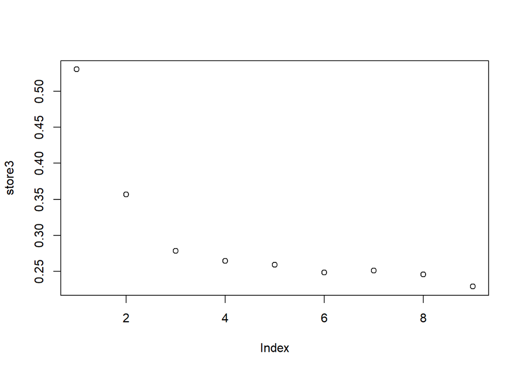

```r
library(ggplot2)
store3 <- c()
for (i in 2:10){
  ct <- cutree(hclust3,k=i)
  si <- silhouette(ct,dist = dist1)
  avg_width <- summary(si)$avg.width
  store3 <- c(store3,avg_width)
}

plot(store3)
```

1)single linkage has the error of 0.17 for k=4( which is estimated to be best cluster size)

2)average linkage has the error of 0.33 for k=4( which is estimated to be best cluster size)

3)complete linkage has the error of 0.28 for k=4( which is estimated to be best cluster size)

We cluster the data using Single Linkage

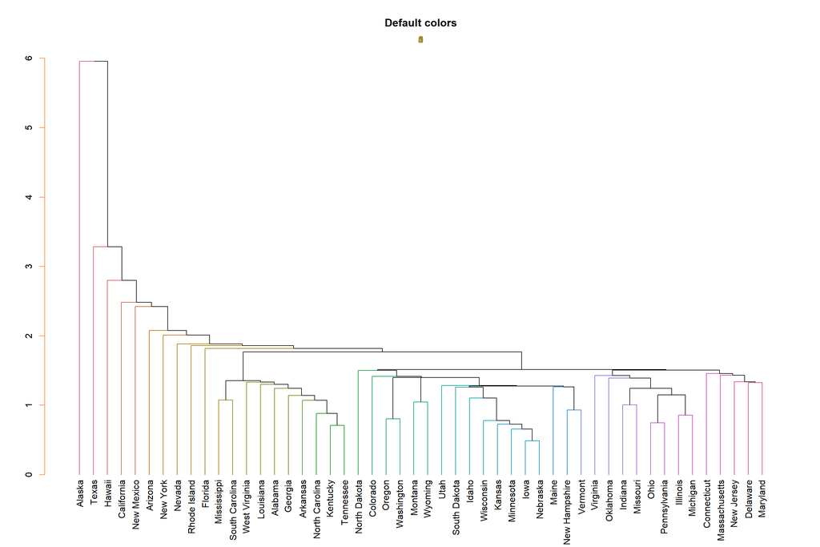

```r
dend1 <- as.dendrogram(hclust1)
dend1 %>% set("branches_k_color") %>%
  plot(main = "Default colors") %>%
  axis(side = 2,col = "#F38630",labels = TRUE) %>%
  mtext(col = "#A38630")
```

```r
cutree1 <- cutree(dend1,4)
cutree1
```

```
##        Alabama         Alaska        Arizona       Arkansas     California
##              1              2              1              1              1
##       Colorado    Connecticut       Delaware        Florida        Georgia
##              1              1              1              1              1
##         Hawaii          Idaho       Illinois        Indiana           Iowa
##              3              1              1              1              1
##         Kansas       Kentucky      Louisiana          Maine       Maryland
##              1              1              1              1              1
##  Massachusetts       Michigan      Minnesota    Mississippi       Missouri
##              1              1              1              1              1
##        Montana       Nebraska         Nevada  New Hampshire     New Jersey
##              1              1              1              1              1
##     New Mexico       New York North Carolina   North Dakota           Ohio
##              1              1              1              1              1
##       Oklahoma         Oregon   Pennsylvania   Rhode Island South Carolina
##              1              1              1              1              1
##   South Dakota      Tennessee          Texas           Utah        Vermont
##              1              1              4              1              1
##       Virginia     Washington  West Virginia      Wisconsin        Wyoming
##              1              1              1              1              1
```

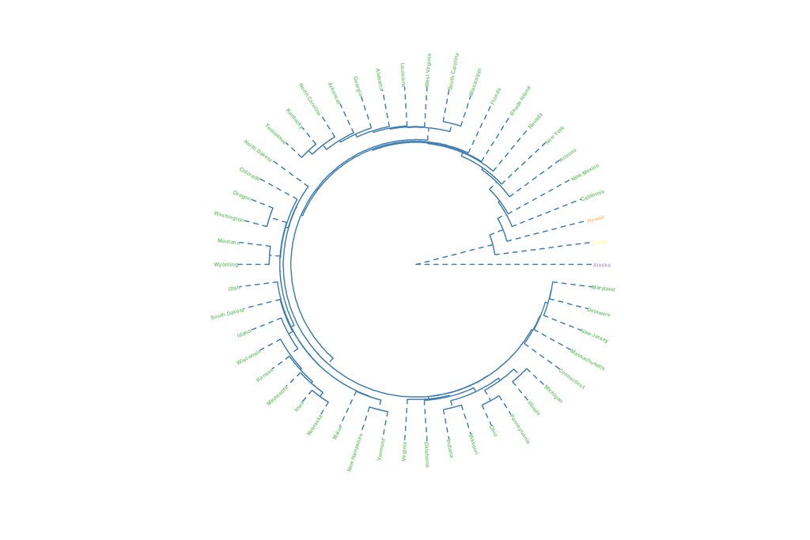

```r
plot(as.phylo(hclust1), type = "fan", cex = 0.6,
    tip.color = brewer.pal(4, 'Accent')[cutree1],
      font = 2,
     edge.color = 'steelblue', edge.width = 2, edge.lty = 2)
```

As we can observe from the fan plot most of thee data gets clustered into the same class.

##AVERAGE LINKAGE

We cluster the data using Average Linkage.

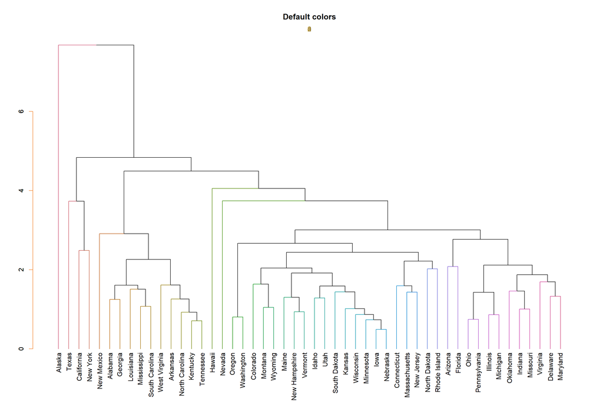

```r
dend2 <- as.dendrogram(hclust2)
dend2 %>% set("branches_k_color") %>%
  plot(main = "Default colors") %>%
  axis(side = 2,col = "#F38630",labels = TRUE) %>%
  mtext(col = "#A38630")
```

We compute Mean intercluster dissimilarity. Compute all pairwise dissimilarities between the observations in cluster A and the observations in cluster B, and record the average of these dissimilarities.

```r
cutree2 <- cutree(dend2,4)
cutree2
```

```
##        Alabama         Alaska        Arizona       Arkansas     California
##              1              2              3              1              4
##       Colorado    Connecticut       Delaware        Florida        Georgia
##              3              3              3              3              1
##         Hawaii          Idaho       Illinois        Indiana           Iowa
##              3              3              3              3              3
##         Kansas       Kentucky      Louisiana          Maine       Maryland
##              3              1              1              3              3
##  Massachusetts       Michigan      Minnesota    Mississippi       Missouri
##              3              3              3              1              3
##        Montana       Nebraska         Nevada  New Hampshire     New Jersey
##              3              3              3              3              3
##     New Mexico       New York North Carolina   North Dakota           Ohio
##              1              4              1              3              3
##       Oklahoma         Oregon   Pennsylvania   Rhode Island South Carolina
##              3              3              3              3              1
##   South Dakota      Tennessee          Texas           Utah        Vermont
##              3              1              4              3              3
##       Virginia     Washington  West Virginia      Wisconsin        Wyoming
##              3              3              1              3              3
```

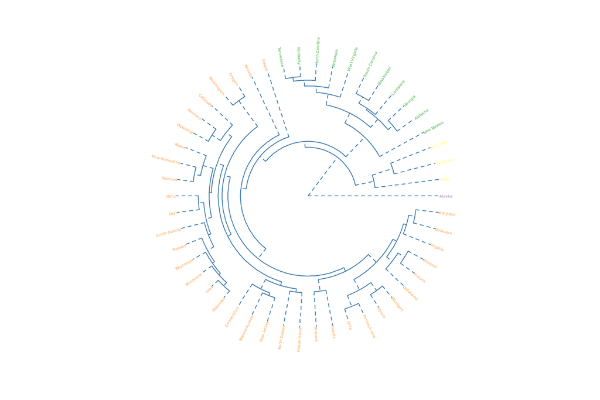

```r
plot(as.phylo(hclust2), type = "fan", cex = 0.6,
    tip.color = brewer.pal(4, 'Accent')[cutree2],
      font = 2,
     edge.color = 'steelblue', edge.width = 2, edge.lty = 2)
```

As we can observe from the fan plot the data gets clustered into four classes.

##COMPLETE LINKAGE

We cluster the data using Complete Linkage.

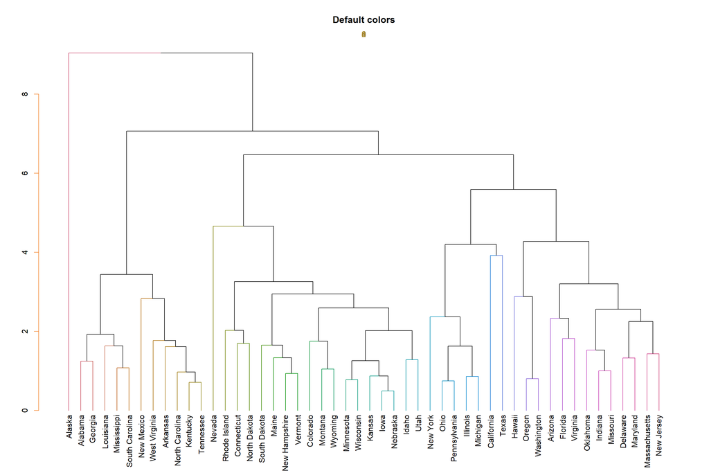

```r
dend3 <- as.dendrogram(hclust3)
dend3 %>% set("branches_k_color") %>%
  plot(main = "Default colors") %>%
  axis(side = 2,col = "#F38630",labels = TRUE) %>%
  mtext(col = "#A38630")
```

We compute Maximal intercluster dissimilarity. Compute all pairwise dissimilarities between the observations in cluster A and the observations in cluster B, and record the largest of these dissimilarities

```r
cutree3 <- cutree(dend3,4)
cutree3
```

```
##        Alabama         Alaska        Arizona       Arkansas     California
##              1              2              3              1              3
##       Colorado    Connecticut       Delaware        Florida        Georgia
##              4              4              3              3              1
##         Hawaii          Idaho       Illinois        Indiana           Iowa
##              3              4              3              3              4
##         Kansas       Kentucky      Louisiana          Maine       Maryland
##              4              1              1              4              3
##  Massachusetts       Michigan      Minnesota    Mississippi       Missouri
##              3              3              4              1              3
##        Montana       Nebraska         Nevada  New Hampshire     New Jersey
##              4              4              4              4              3
##     New Mexico       New York North Carolina   North Dakota           Ohio
##              1              3              1              4              3
##       Oklahoma         Oregon   Pennsylvania   Rhode Island South Carolina
##              3              3              3              4              1
##   South Dakota      Tennessee          Texas           Utah        Vermont
##              4              1              3              4              4
##       Virginia     Washington  West Virginia      Wisconsin        Wyoming
##              3              3              1              4              4
```

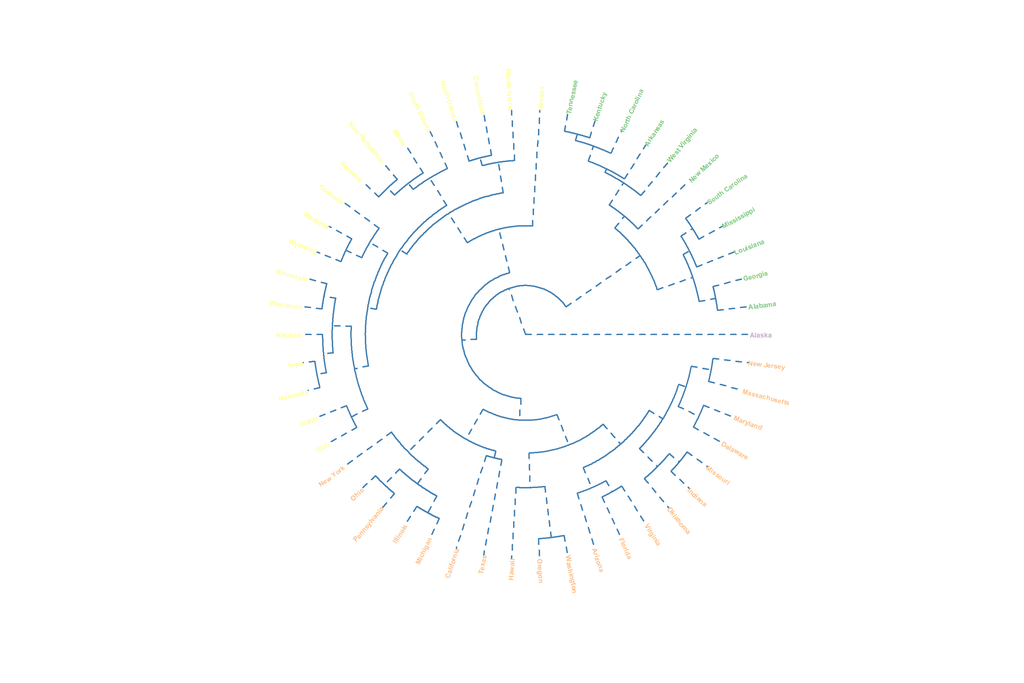

```r
plot(as.phylo(hclust3), type = "fan", cex = 0.6,
    tip.color = brewer.pal(4, 'Accent')[cutree3],
      font = 2,
     edge.color = 'steelblue', edge.width = 2, edge.lty = 2)
```

##RESULT

From the Results of the Above Clustering we observe that the Heirarchical Clustering using Complete Linkage gives us the best results. The Cluster using the Single Linkage gives us the worst results (The tree is completely unbalanced) and the cluster uysing the Average Linkage gives us moderate results. The tree is relatively unbalanced in comparison to the complete linkage tree.

##SOM

```r
training_data <- as.matrix(df1)
```

```r
data_train_matrix <- training_data
som_grid <- somgrid(xdim = 3, ydim=4, topo="hexagonal")
som_model <- som(data_train_matrix,grid=som_grid,rlen=10000)
```

The counts lot gives us the count of the number of states map into the different units.

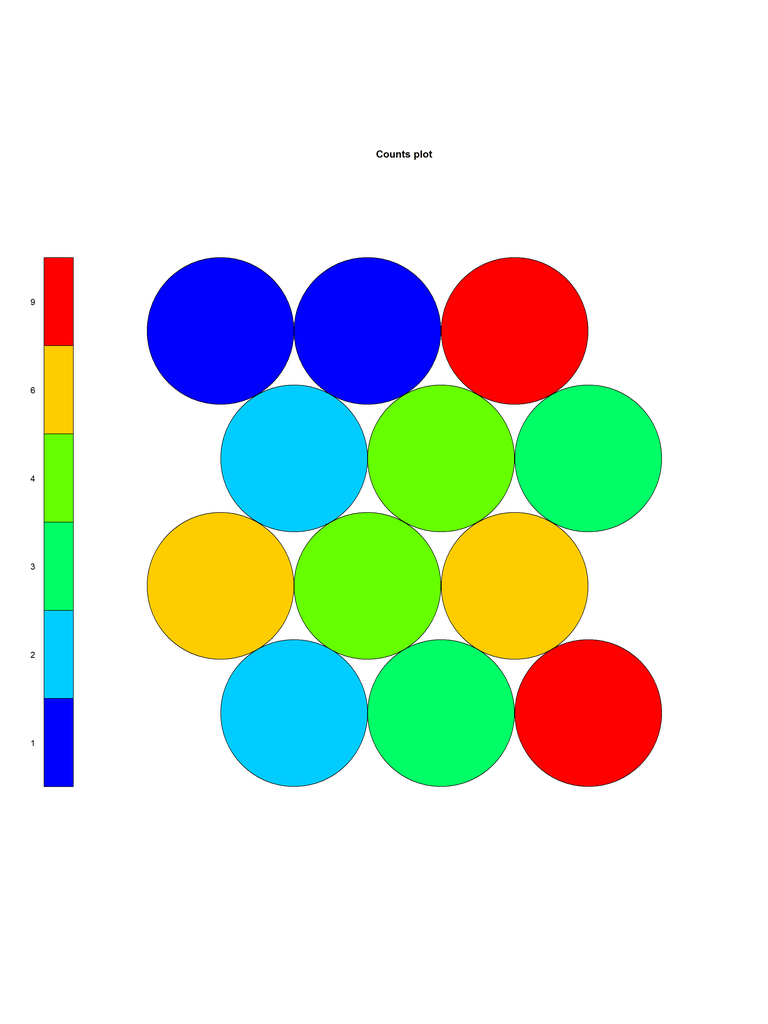

```r
coolBlueHotRed <- function(n,alpha=1){rainbow(n,end=4/6,alpha=alpha)[n:1]}
plot(som_model,type="counts",palette.name=coolBlueHotRed)
```

We now plot all this Information onto a Grid. This further reinforcees the information provided by the above Heat Map.

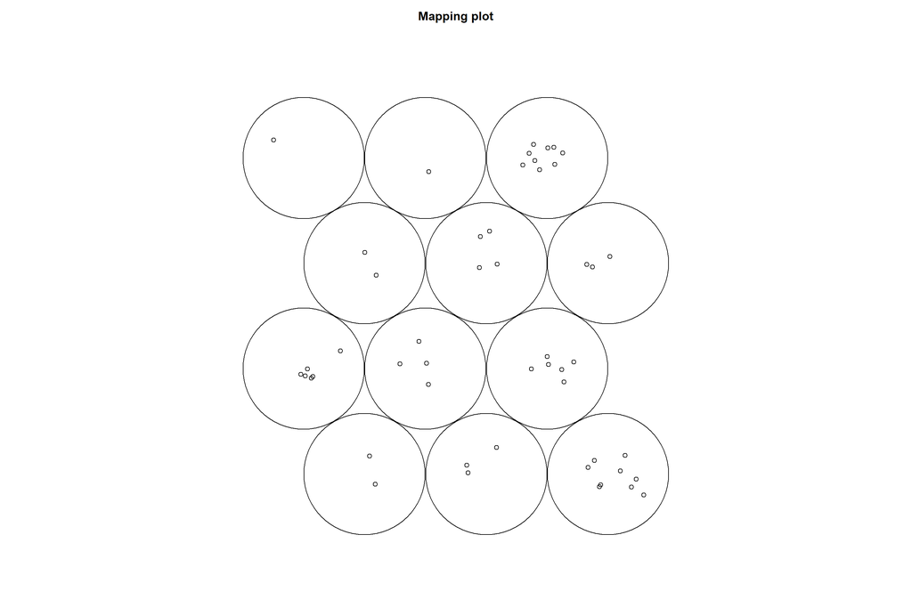

```r
plot(som_model,type="mapping")
```

This gives us the summary of the Self Organization Map.

```r
summary(som_model)
```

```
## SOM of size 3x4 with a hexagonal topology and a bubble neighbourhood function.
## The number of data layers is 1.
## Distance measure(s) used: sumofsquares.
## Training data included: 50 objects.
## Mean distance to the closest unit in the map: 24991799.
```

```r
som_model$codes
```

```
## [[1]]
##     Population   Income Illiteracy Life Exp    Murder  HS Grad     Frost
## V1    1156.566 4354.912  0.5551062 72.36655  2.361274 56.60637 153.81496
## V2    1904.443 3648.134  1.4789416 69.25826  7.068446 44.56140 107.90037
## V3    2941.847 4814.440  1.0878048 71.51877  5.025594 55.18286 109.51240
## V4    1446.424 4601.060  1.0038256 70.65971  7.844859 61.18368 121.13808
## V5    1956.685 4328.874  0.6000000 72.57334  4.187691 61.43272 135.16841
## V6    3869.937 3839.035  1.7854495 69.58854 10.738629 43.66007  72.55776
## V7   11604.592 4754.224  0.8654653 71.17057  7.813932 61.00516  83.32437
## V8    2716.672 4594.218  0.8217399 71.76117  4.925682 53.79773 104.75037
## V9   13518.833 4630.305  1.0672164 70.58957  8.052775 51.93666 111.17152
## V10    365.000 6315.000  1.5000000 69.31000 11.300000 66.70000 152.00000
## V11  12237.000 4188.000  2.2000000 70.90000 12.200000 47.40000  35.00000
## V12   5625.492 4260.385  1.3814219 70.38318  9.918474 47.51499  84.92621
##          Area
## V1   76245.96
## V2   28389.40
## V3    6633.25
## V4  106311.79
## V5   81519.07
## V6   41827.91
## V7  151307.25
## V8   68388.04
## V9   44654.87
## V10 566432.00
## V11 262134.00
## V12  54010.46
```

We now analyze the list of all the states and the prototypes that are closest to them.

```r
som_model$unit.classif
```

```
##  [1] 12 10  4 12  7  4  3  3 12 12  3  5 12  6 12  5  6  6  2  3  3 12  5  6  8
## [26]  7  1  4  3  3  4  9 12  8  9  8  4  9  3  2  1  6 11  5  3  6  8  2 12  4
```

```r
head(som_model$changes)
```

```
##           [,1]
## [1,] 3027.5653
## [2,] 2959.8282
## [3,] 1118.4058
## [4,] 2902.7034
## [5,] 3972.5939
## [6,]  976.1232
```

We observe that the changes start decreasing as we start increasing the number of iterations. A better understanding can be obtained from the Graph which represents the changes in the prototype. The things start converging as we move in the iteration.

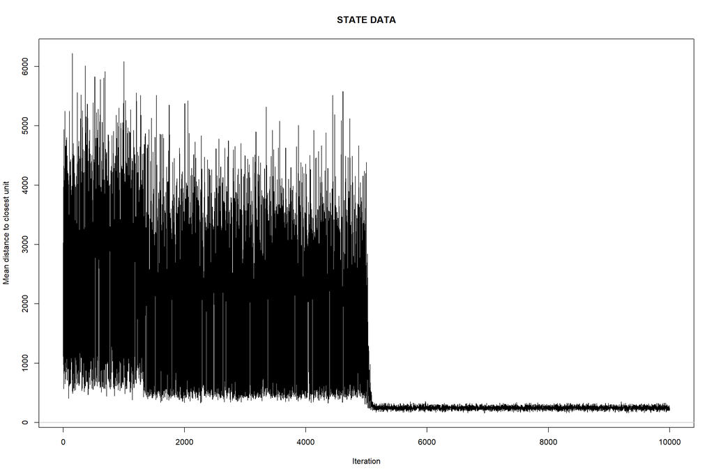

```r
plot(som_model,type="changes",main="STATE DATA")
```

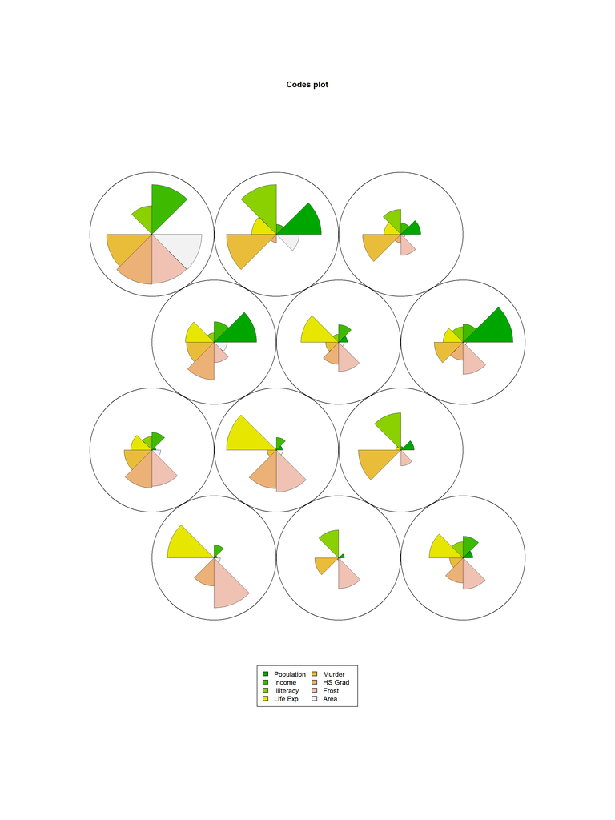

```r
plot(som_model,type = "codes")
```

We now plot the distance to the Neighbours between each states that are plotted into a particular node.

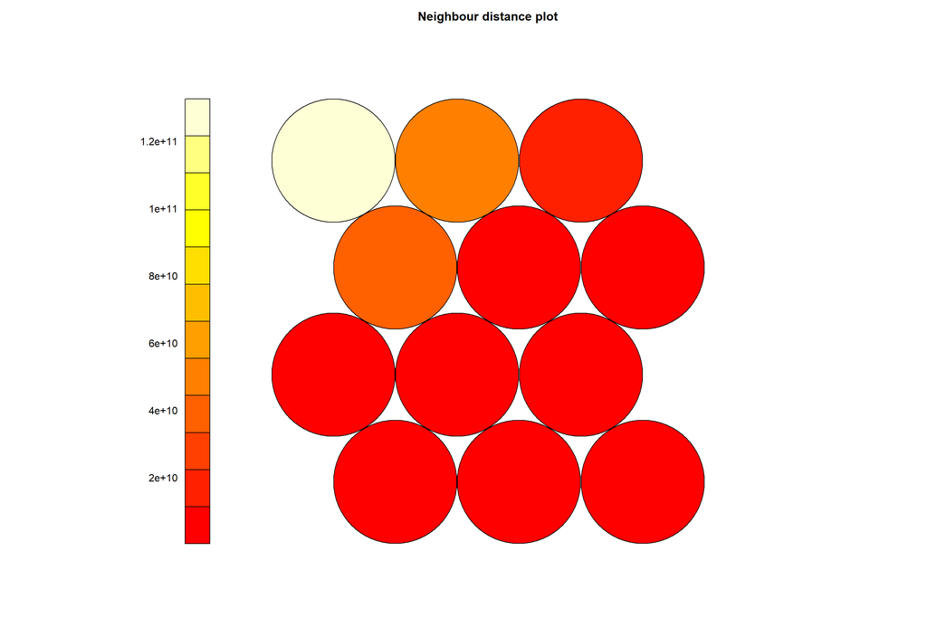

```r
plot(som_model,type="dist.neighbours")
```

We now plot the componenet plane plots. Which Visualizes the original data over the SOM that we have created.

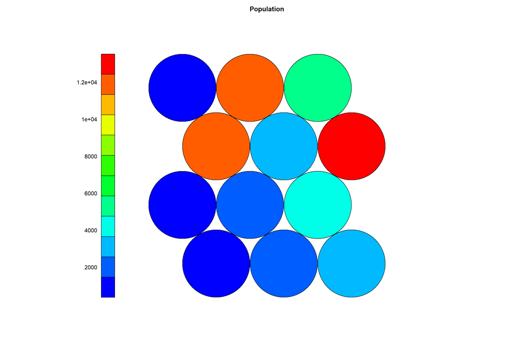

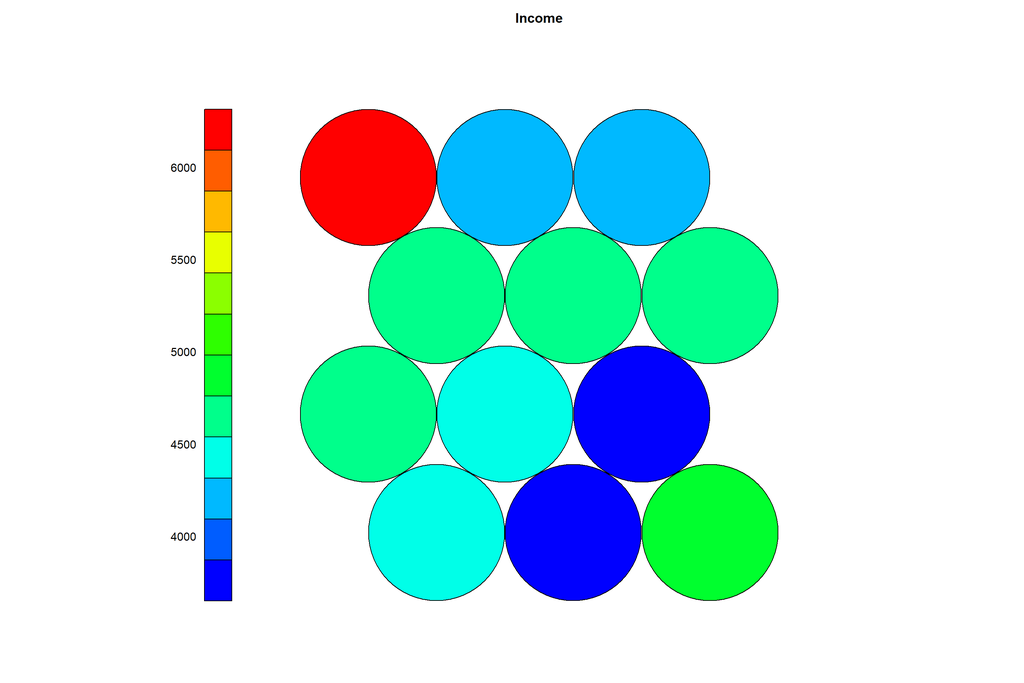

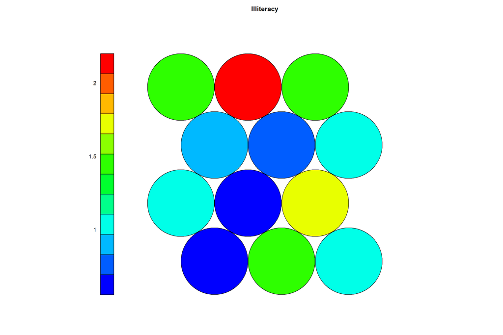

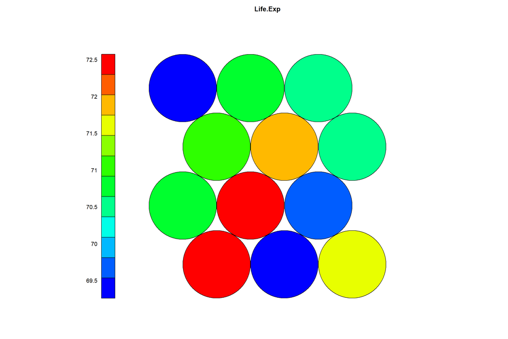

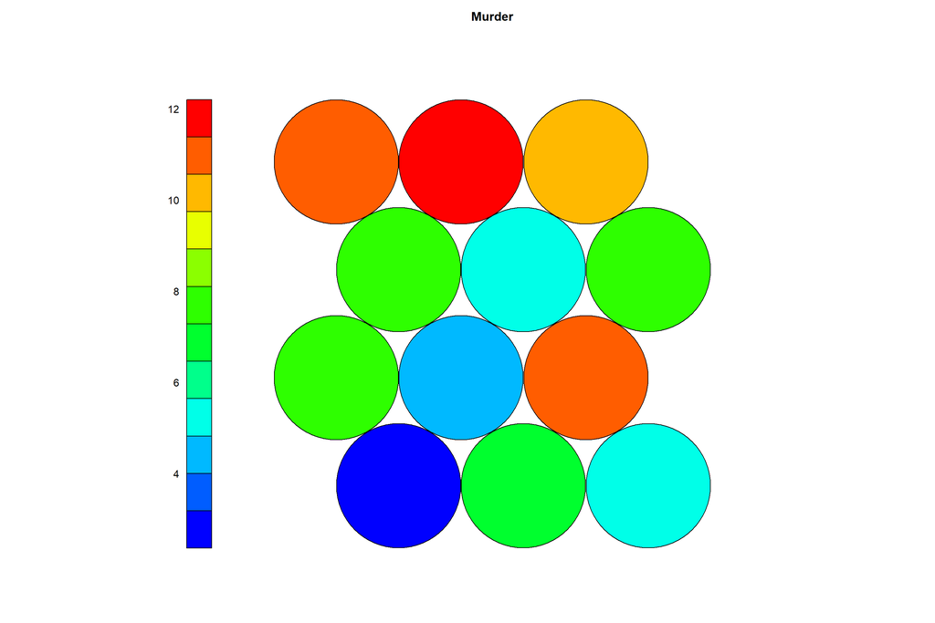

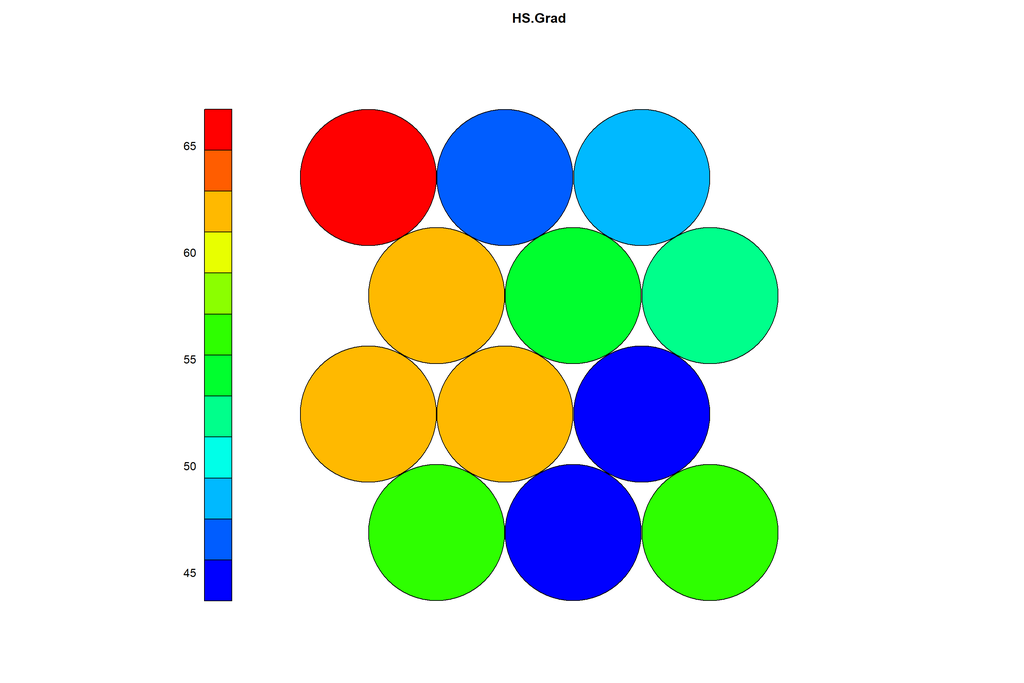

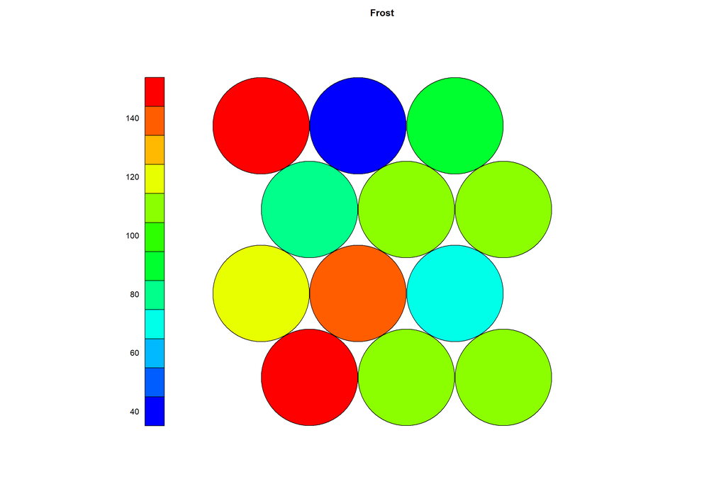

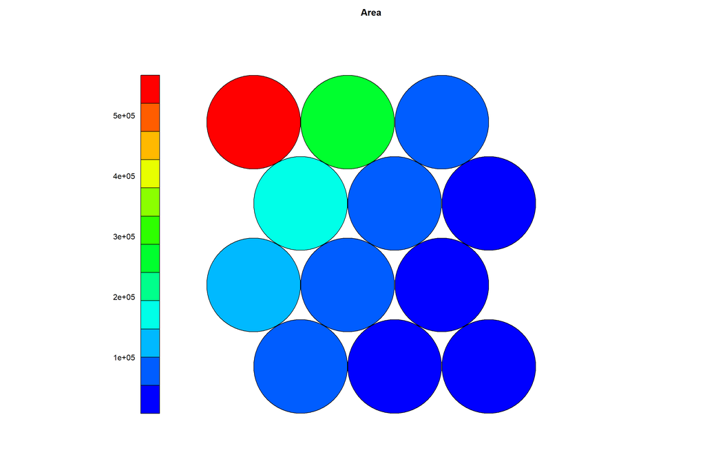

```r
codes <- som_model$codes[[1]]

som_model$data <- data.frame(som_model$data)
for (i in 1:8){
  plot(som_model, type = "property", property = codes[,i], main=names(som_model$data)[i],palette.name=coolBlueHotRed)
  }
```

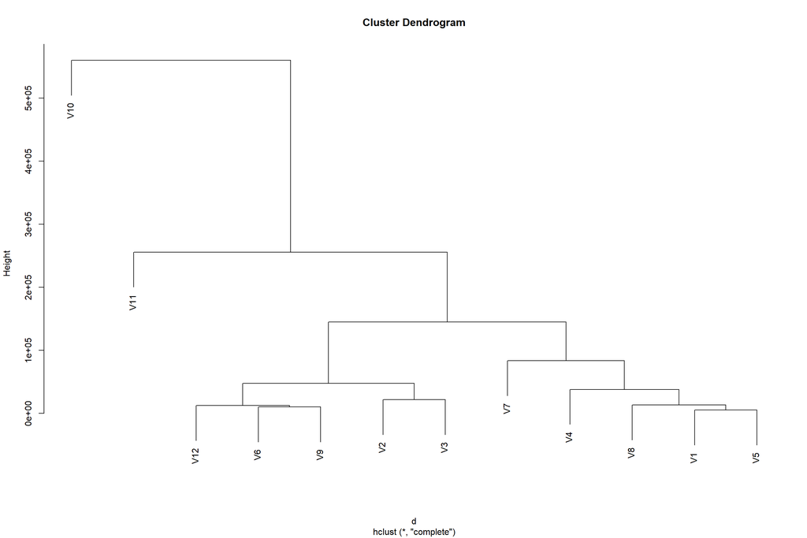

```r
d <- dist(codes)
hc <- hclust(d)
plot(hc)
```

We now plot the SOM amd specify the cutoff point at a location where we can observe the approximate cutoff in the Dendrogram plotted above.

By specifying the cutoff point obtained from the plot above and clustering the data at that height gives us the approximate distribution of the data into 4 clusters.

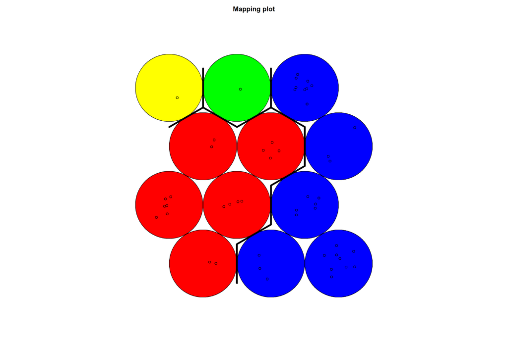

```r
som_cluster <- cutree(hc,k=4)
# plot these results:
my_pal <- c("red","blue","yellow","green")
my_bhcol <- my_pal[som_cluster]

{plot(som_model,type="mapping",col="black",bgcol = my_bhcol)
  add.cluster.boundaries(som_model,som_cluster)}
```

##GAUSSIAN GRAPHICAL MODEL

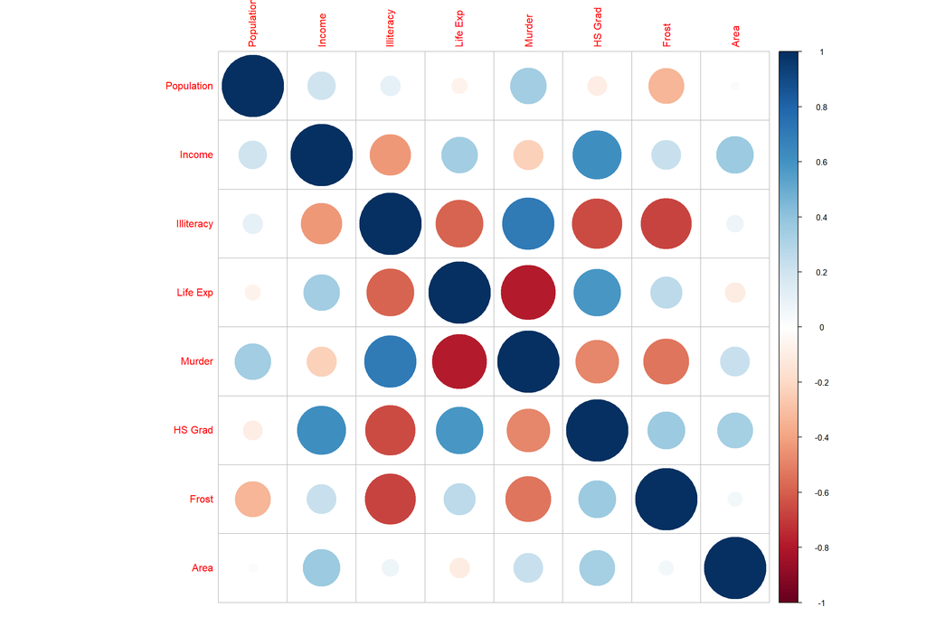

```r
M <- cor(df1)
corrplot(M)
```

We observe from the corrplot that Murder and Life Expectency are Negatively correlated. So we remove one of these variables.

We also take a look at the distribution of the data given below.

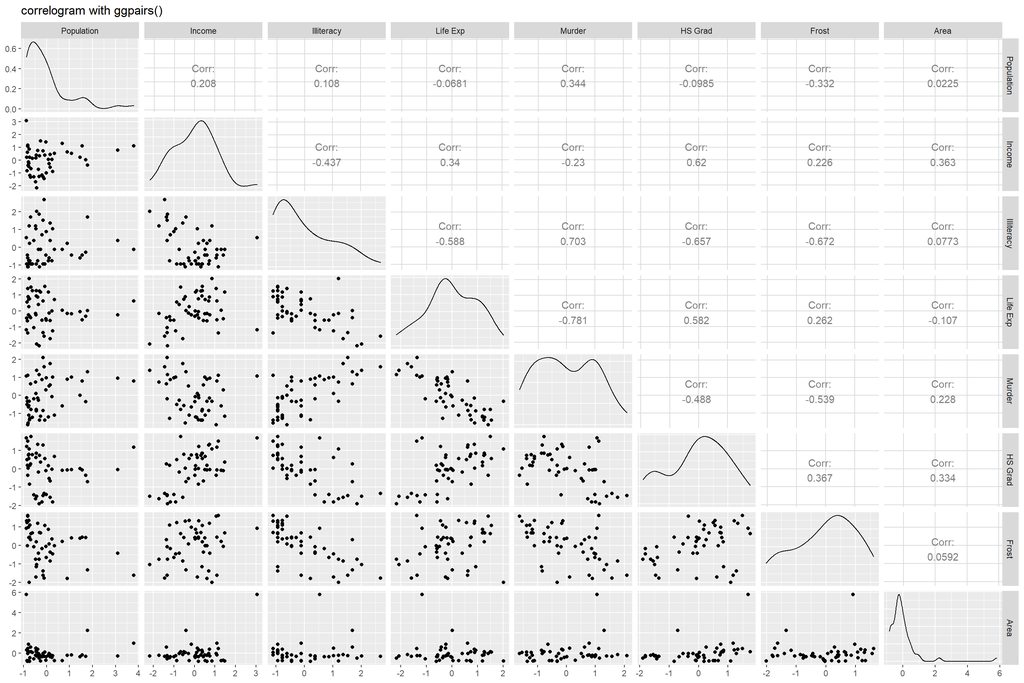

```r
df1_1 <- as.data.frame(z)
ggpairs(df1_1, title="correlogram with ggpairs()")
```

```r
dats <- z[,-5]
```

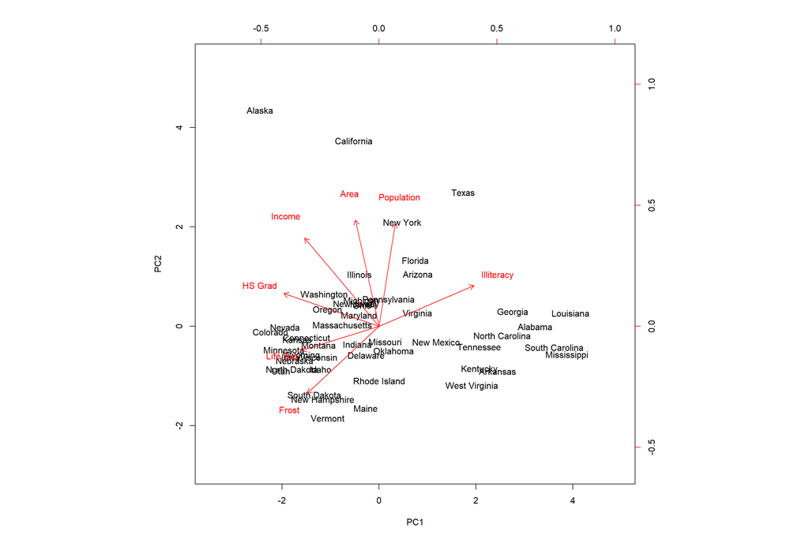

```r
fit_pca <- prcomp(dats)
xlim_1 <- min(fit_pca$x[,1])-1
xlim_2 <- max(fit_pca$x[,1])+1
ylim_1 <- min(fit_pca$x[,2])-1
ylim_2 <- max(fit_pca$x[,2])+1

biplot(fit_pca,choices = c(1,2),scale = 0,xlim=c(xlim_1,xlim_2),ylim=c(ylim_1,ylim_2))
```

We observe from the Biplot that Alaska, California and Texas are outliers and needs to be removed.

```r
new_dats <- dats[-c(2,5,43),]
```

Now we take a look at the partial correlation

```r
part1 <- cov.wt(new_dats, method="ML")
PC.body <- cov2pcor(part1$cov)
diag(PC.body) <- 0
```

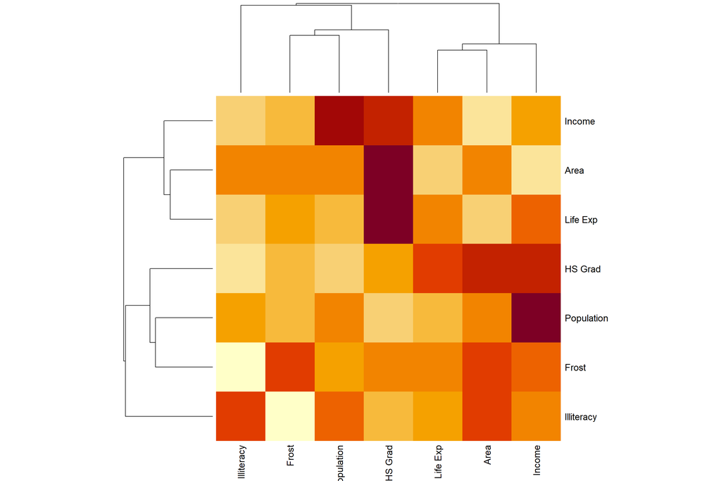

```r
heatmap(PC.body)
```

```r
S <- part1$cov
m0.lasso <- glasso(S,rho=0.1)
my_edges <- m0.lasso$wi!=0
diag(my_edges) <- 0
g.lasso <- as(my_edges,"graphNEL")
nodes(g.lasso) <- colnames(new_dats)
```

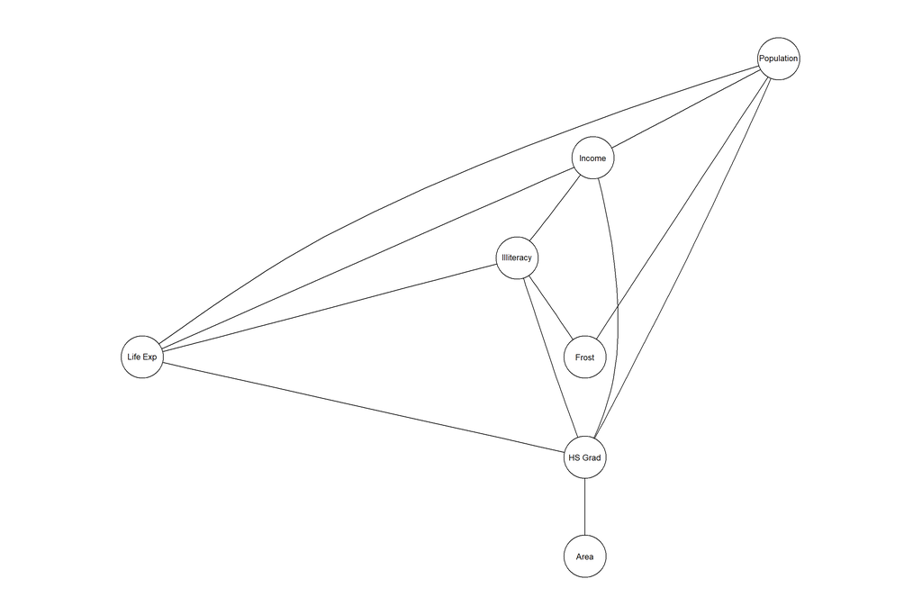

```r
plot(g.lasso)
```

```r
my_rhos <- c(0.1,0.2,0.3,0.4,0.5,0.6)
m0.lasso <- glassopath(S,rho=my_rhos)
```

[output not shown]